## 2021-11-02 Exploratory Battery Data Analysis

This analysis was generated by Ben Langhauser.

This code explores two data sets provided that look at the difference for two fast charging profiles and their effect on cycling and lifetime. The goal for this exercise is to explore the data and see if there are features that can help predict the life of the cell early on in cycling.

```r
# Load in necessary packages
library(dplyr)
```

```r
library(ggplot2)
library(gridExtra)
# Display R/Package Versions
```

The first step is to take a look at the data itself:

```r
# Loading in Data
cell_1 <- read.csv("Cell_11_DE.csv")
cell_3 <- read.csv("Cell_33_DE.csv")

head(cell_1)
```

```
##        X Data_Point Test_Time   DateTime Step_Time Cycle_Index   Current
## 1 513571     513571  4962.282 1494660824    0.0122           1 0.0000000
## 2 513572     513572  4962.447 1494660824    0.0497           1 0.2947426
## 3 513573     513573  4962.470 1494660824    0.0734           1 0.5332298
## 4 513574     513574  4962.502 1494660824    0.1054           1 0.7711678
## 5 513575     513575  4962.517 1494660824    0.1206           1 0.9488564
## 6 513576     513576  4962.531 1494660824    0.1343           1 1.0697823
##    Voltage Charge_Capacity Discharge_Capacity Charge_Energy Discharge_Energy
## 1 2.019667    0.000000e+00       0.000000e+00  0.000000e+00     0.000000e+00
## 2 2.032751    1.197732e-06       7.187523e-10  2.428934e-06     1.452859e-09
## 3 2.048826    1.197732e-06       7.187523e-10  2.428934e-06     1.452859e-09
## 4 2.069797    1.197732e-06       7.187523e-10  2.428934e-06     1.452859e-09
## 5 2.088523    1.425226e-05       7.187523e-10  2.936508e-05     1.452859e-09
## 6 2.102028    1.425226e-05       7.187523e-10  2.936508e-05     1.452859e-09
##   Internal_Resistance Temperature Cell_id
## 1          0.01630091    31.78144      11
## 2          0.01630091    31.78144      11
## 3          0.01630091    31.78144      11
## 4          0.01630091    31.78144      11
## 5          0.01630091    31.78144      11
## 6          0.01630091    31.78144      11
```

Next, I wanted to get familiar with the the cycling schedule for each cell:

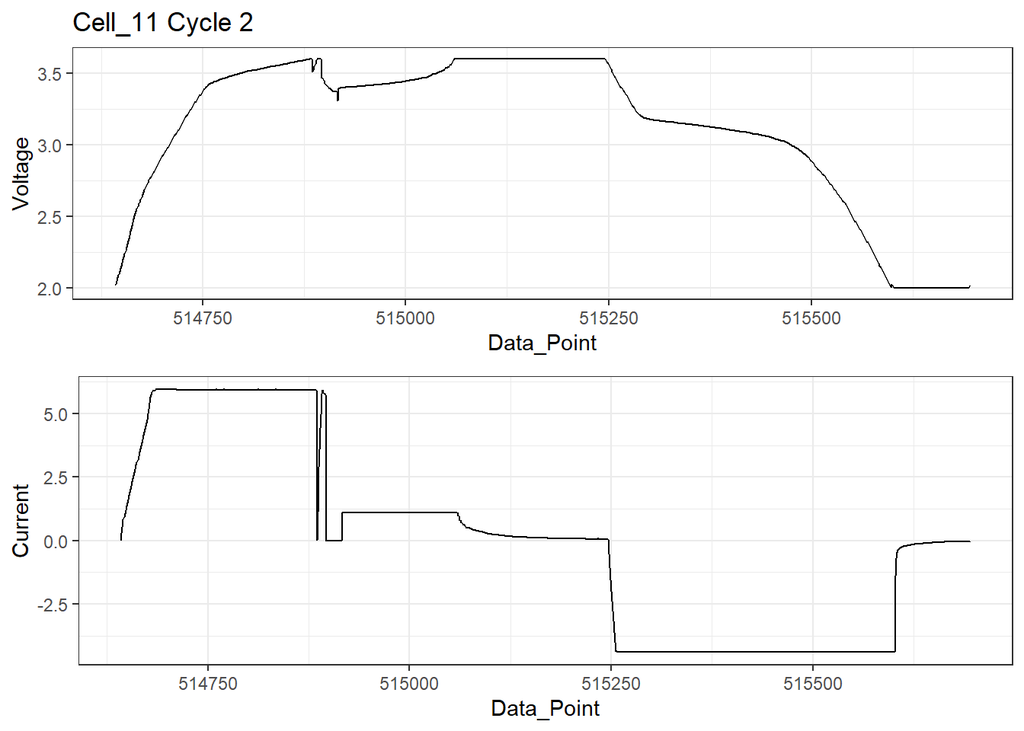

```r
# Loading in Data
p1 <- ggplot(cell_1[cell_1$Cycle_Index == 2,], aes(x=Data_Point, y=Voltage))+geom_line()+labs(title="Cell_11 Cycle 2")+theme_bw()
p2 <- ggplot(cell_1[cell_1$Cycle_Index == 2,], aes(x=Data_Point, y=Current))+geom_line()+theme_bw()
grid.arrange(p1, p2, nrow=2)+theme_bw()
```

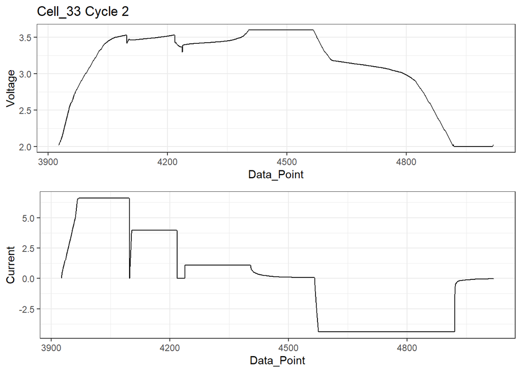

```r
p3 <- ggplot(cell_3[cell_3$Cycle_Index == 2,], aes(x=Data_Point, y=Voltage))+geom_line()+labs(title="Cell_33 Cycle 2")+theme_bw()
p4 <- ggplot(cell_3[cell_3$Cycle_Index == 2,], aes(x=Data_Point, y=Current))+geom_line()+theme_bw()
grid.arrange(p3, p4, nrow=2)
```

Now that the cycling schedule is confirmed for each battery, we can start to take a look at how the battery is performing over the duration of the test. While looking at a time series plot works well for a single cycle, it quickly becomes unusable once you are looking at many different cycles. For me, the best way to visualize battery voltage curves (or any data) over a lifetime is a “Waterfall” plot. To avoid plotting a large amount of we will subset the cycles at a regular interval.

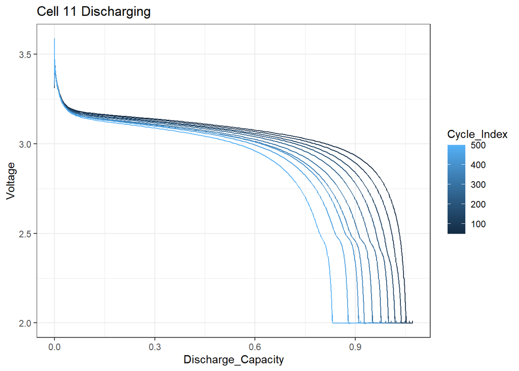

```r
# These plots Look at every 50th cycle
ggplot(cell_1[cell_1$Cycle_Index %% 50 == 0 & cell_1$Current < 0, ], aes(x=Discharge_Capacity, y=Voltage, group=Cycle_Index, color=Cycle_Index))+geom_line()+theme_bw()+labs(title="Cell 11 Discharging")
```

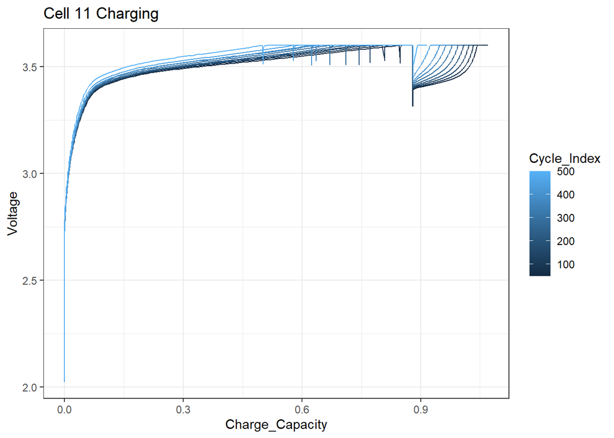

```r
ggplot(cell_1[cell_1$Cycle_Index %% 50 == 0 & cell_1$Current > 0, ], aes(x=Charge_Capacity, y=Voltage, group=Cycle_Index, color=Cycle_Index))+geom_line()+theme_bw()+labs(title="Cell 11 Charging")
```

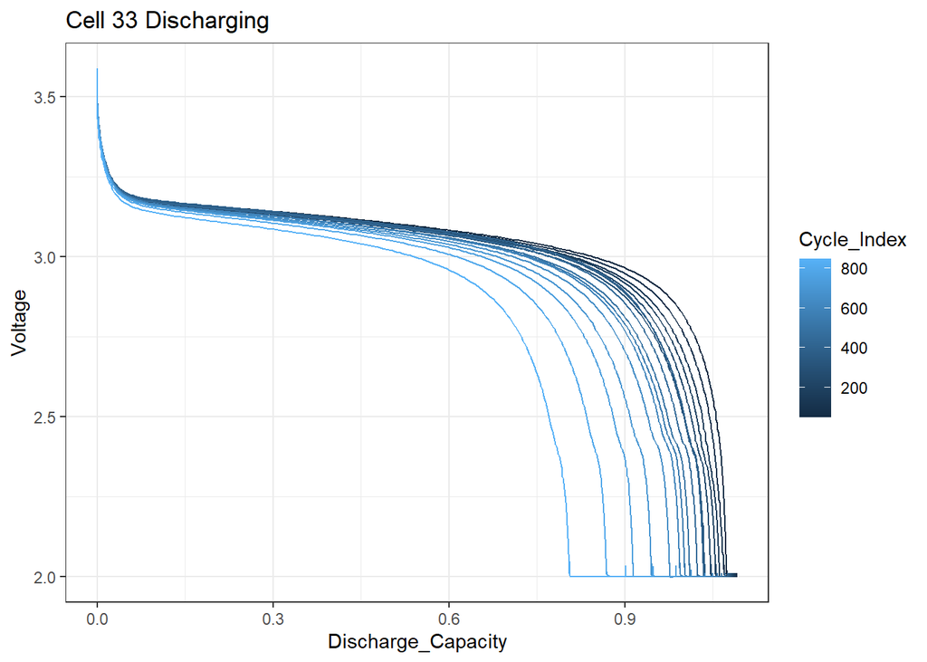

```r
ggplot(cell_3[cell_3$Cycle_Index %% 50 == 0 & cell_3$Current < 0, ], aes(x=Discharge_Capacity, y=Voltage, group=Cycle_Index, color=Cycle_Index))+geom_line()+theme_bw()+labs(title="Cell 33 Discharging")
```

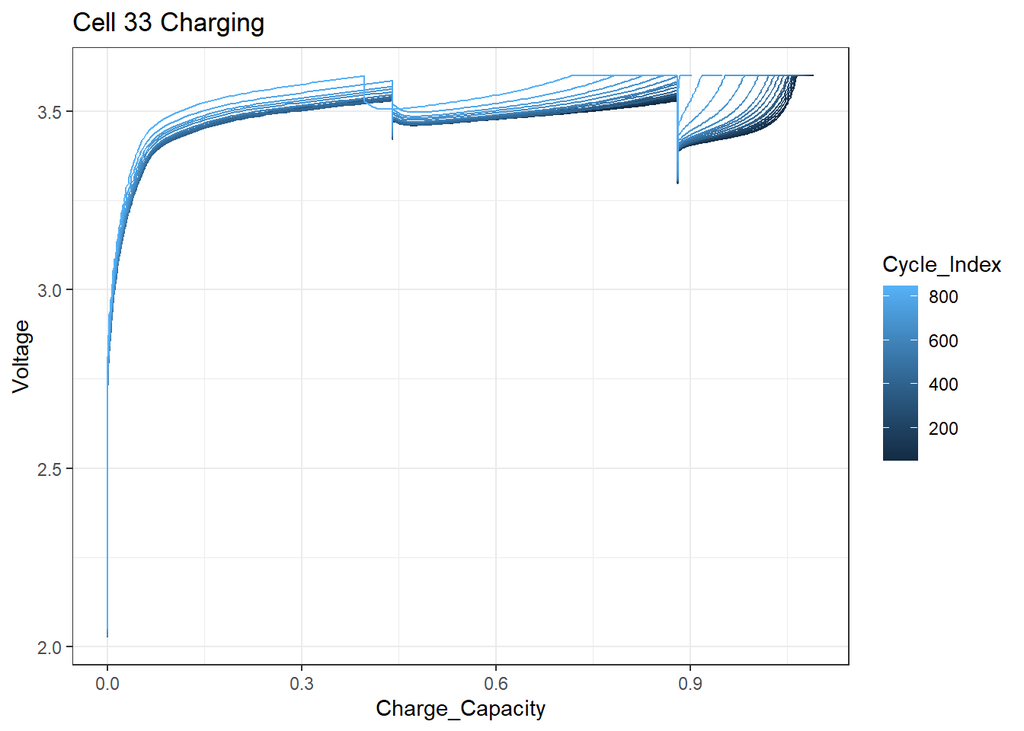

```r
ggplot(cell_3[cell_3$Cycle_Index %% 50 == 0 & cell_3$Current > 0, ], aes(x=Charge_Capacity, y=Voltage, group=Cycle_Index, color=Cycle_Index))+geom_line()+theme_bw()+labs(title="Cell 33 Charging")
```

Along with Voltage Curves, it is useful to look at some other measurements taken during the testing, specifically the Internal Resistance and Temperature Profiles.

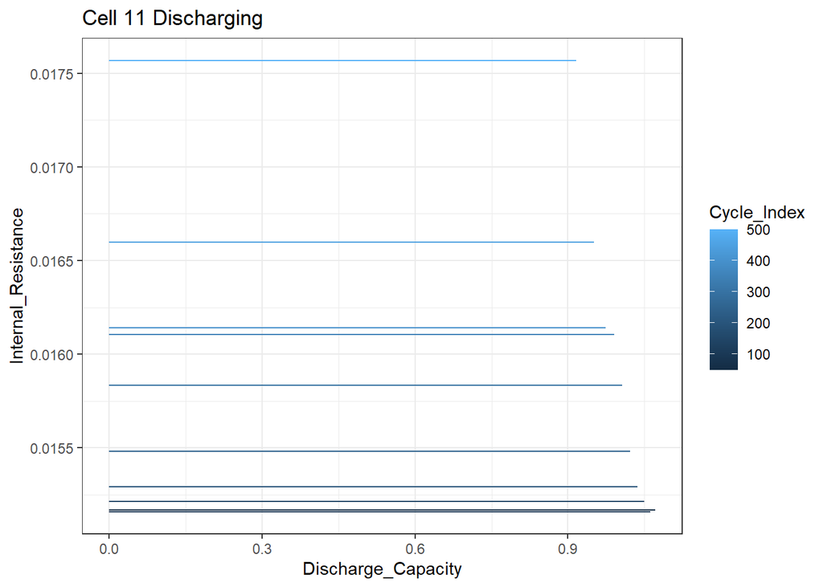

```r
# Internal Resistance vs Cycle Count
ggplot(cell_1[cell_1$Cycle_Index %% 50 == 0 & cell_1$Current < 0, ], aes(x=Discharge_Capacity, y=Internal_Resistance, group=Cycle_Index, color=Cycle_Index))+geom_line()+theme_bw()+labs(title="Cell 11 Discharging")
```

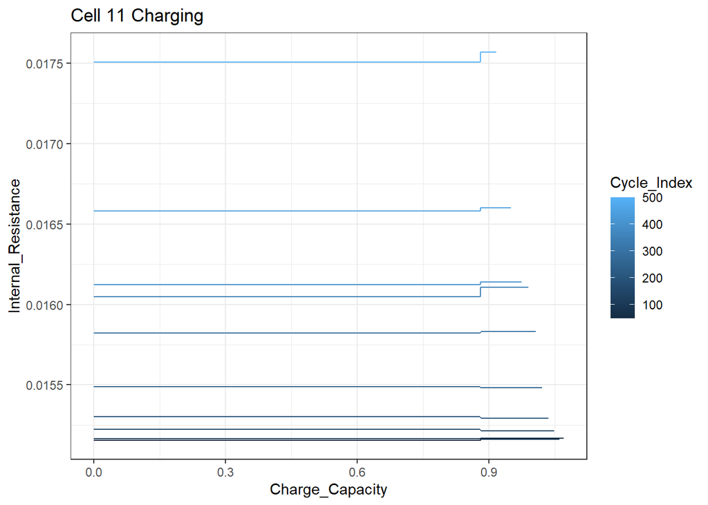

```r
ggplot(cell_1[cell_1$Cycle_Index %% 50 == 0 & cell_1$Current > 0, ], aes(x=Charge_Capacity, y=Internal_Resistance, group=Cycle_Index, color=Cycle_Index))+geom_line()+theme_bw()+labs(title="Cell 11 Charging")
```

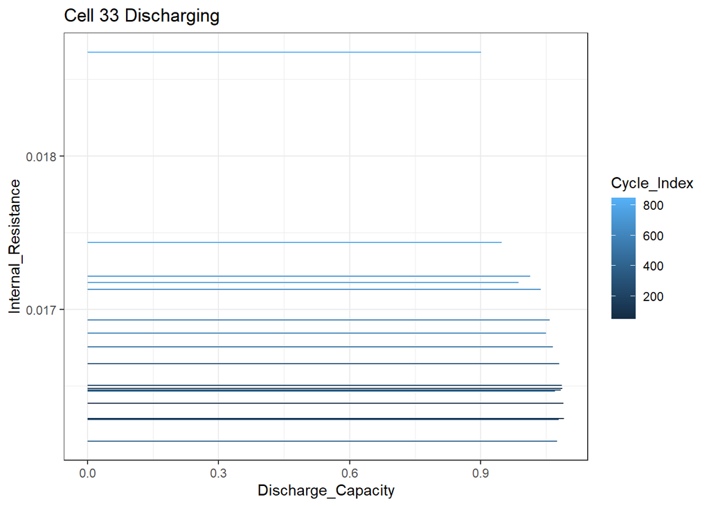

```r
ggplot(cell_3[cell_3$Cycle_Index %% 50 == 0 & cell_3$Current < 0, ], aes(x=Discharge_Capacity, y=Internal_Resistance, group=Cycle_Index, color=Cycle_Index))+geom_line()+theme_bw()+labs(title="Cell 33 Discharging")
```

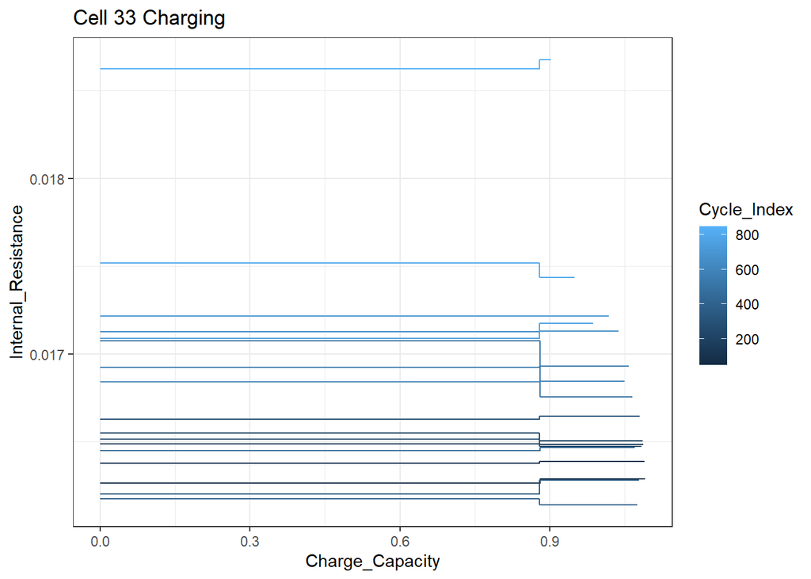

```r
ggplot(cell_3[cell_3$Cycle_Index %% 50 == 0 & cell_3$Current > 0, ], aes(x=Charge_Capacity, y=Internal_Resistance, group=Cycle_Index, color=Cycle_Index))+geom_line()+theme_bw()+labs(title="Cell 33 Charging")
```

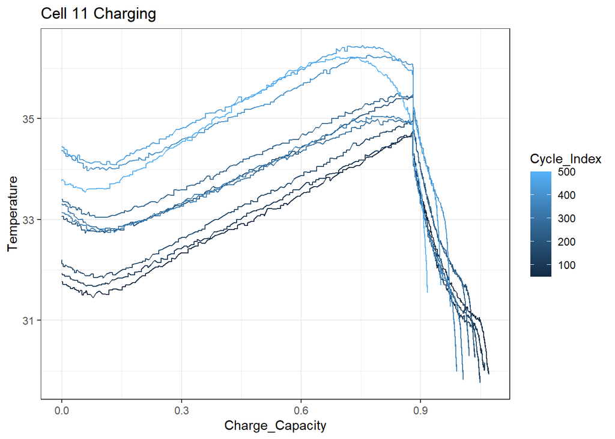

```r
# Temp vs Cycle Count
ggplot(cell_1[cell_1$Cycle_Index %% 50 == 0 & cell_1$Current > 0, ], aes(x=Charge_Capacity, y=Temperature, group=Cycle_Index, color=Cycle_Index))+geom_line()+theme_bw()+labs(title="Cell 11 Charging")
```

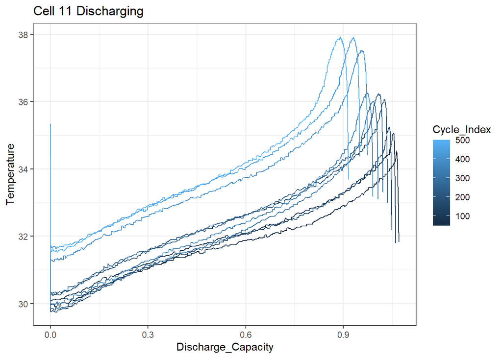

```r
ggplot(cell_1[cell_1$Cycle_Index %% 50 == 0 & cell_1$Current < 0, ], aes(x=Discharge_Capacity, y=Temperature, group=Cycle_Index, color=Cycle_Index))+geom_line()+theme_bw()+labs(title="Cell 11 Discharging")
```

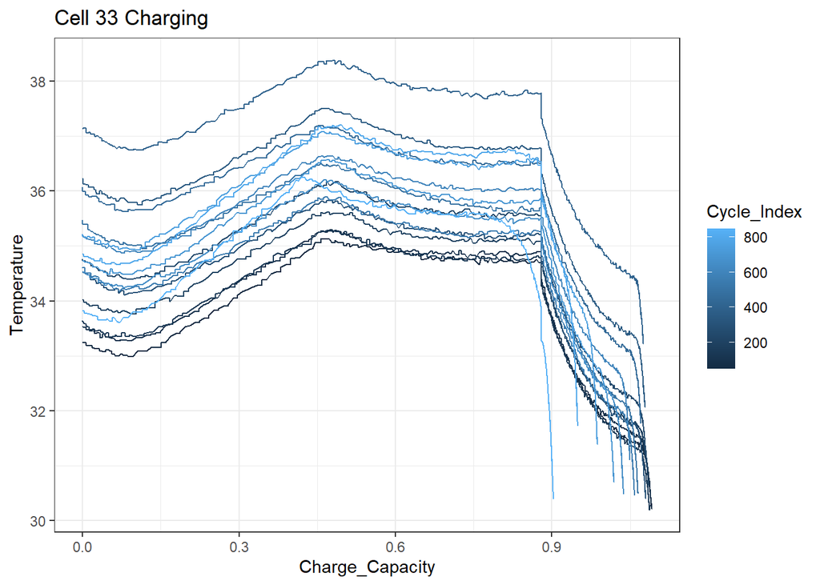

```r
ggplot(cell_3[cell_3$Cycle_Index %% 50 == 0 & cell_3$Current > 0, ], aes(x=Charge_Capacity, y=Temperature, group=Cycle_Index, color=Cycle_Index))+geom_line()+theme_bw()+labs(title="Cell 33 Charging")
```

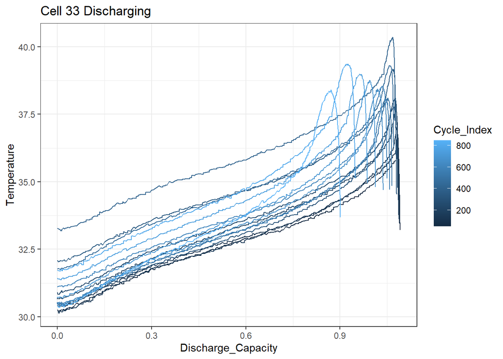

```r
ggplot(cell_3[cell_3$Cycle_Index %% 50 == 0 & cell_3$Current < 0, ], aes(x=Discharge_Capacity, y=Temperature, group=Cycle_Index, color=Cycle_Index))+geom_line()+theme_bw()+labs(title="Cell 33 Discharging")
```

Now that we have a good sense of how the data is changing over the course of the lifetime, it would be a good idea to start creating some new features to continue to investigate the cell performance over its lifetime. We will generate a series of cycle summary statistics to significantly reduce the amount of data needed to plot the whole cycle lifetime.

```r
# This function takes in a data frame from one cell test and summaries each cycle to generate new features for analysis
cycle_summary <- function(cell_df){
  # Full Cycle Summary
  summ_data <- cell_df %>% group_by(Cycle_Index)%>%summarise(
    charge_cap=max(Charge_Capacity), # Cycle Charge Capacity
    discharge_cap=max(Discharge_Capacity), # Cycle Discharge Capacity
    charge_eng=max(Charge_Energy), # Cycle Charge Energy
    discharge_eng=max(Discharge_Energy), # Cycle Discharge Energy
    Q_eff = max(Discharge_Capacity)/max(Charge_Capacity), # Cycle Coulombic Efficiency [Ah/Ah]
    DC_eff = max(Discharge_Energy)/max(Charge_Energy)) # Cycle Energy Efficiency [Wh/Wh]

  # Charging Data Only Summary
  summ_data_chg <- cell_df %>%filter(Current > 0)%>%group_by(Cycle_Index)%>%summarise(
    chg_V_avg = mean(Voltage), # Average Charging Voltage
    chg_ir_avg = mean(Internal_Resistance), # Average Charging Internal Resistance
    chg_temp_avg = mean(Temperature), # Average Charging Temp
    chg_curr_avg = mean(Current), # Average Charging Current
    chg_temp_diff = max(Temperature)-min(Temperature) # Temperature Difference during Charge
  )

  # Discharging Data Only Summary
  summ_data_dchg <- cell_df %>%filter(Current < 0)%>%group_by(Cycle_Index)%>%summarise(
    dchg_V_avg = mean(Voltage), # Average Discharging Voltage
    dchg_ir_avg = mean(Internal_Resistance), # Average Discharge Internal Resistance
    dchg_temp_avg = mean(Temperature), # Average Discharging Temp
    dchg_curr_avg = mean(Current), # Average Discharging Current
    dchg_temp_diff = max(Temperature)-min(Temperature) # Temperature Difference during Charge
  )

  summ_data <- left_join(summ_data, summ_data_chg, by="Cycle_Index")
  summ_data <- left_join(summ_data, summ_data_dchg, by="Cycle_Index")

  summ_data$Cell_id <- cell_df[1,'Cell_id']
  return(summ_data)
}

cell_1_summ <- cycle_summary(cell_1)
cell_3_summ <- cycle_summary(cell_3)
cell_summ <- rbind(cell_1_summ, cell_3_summ)
```

With these cycle level statistics, it is much easier to take a look at the whole picture of a cells lifetime. The first thing to look at is the Full Cycle summary stats.

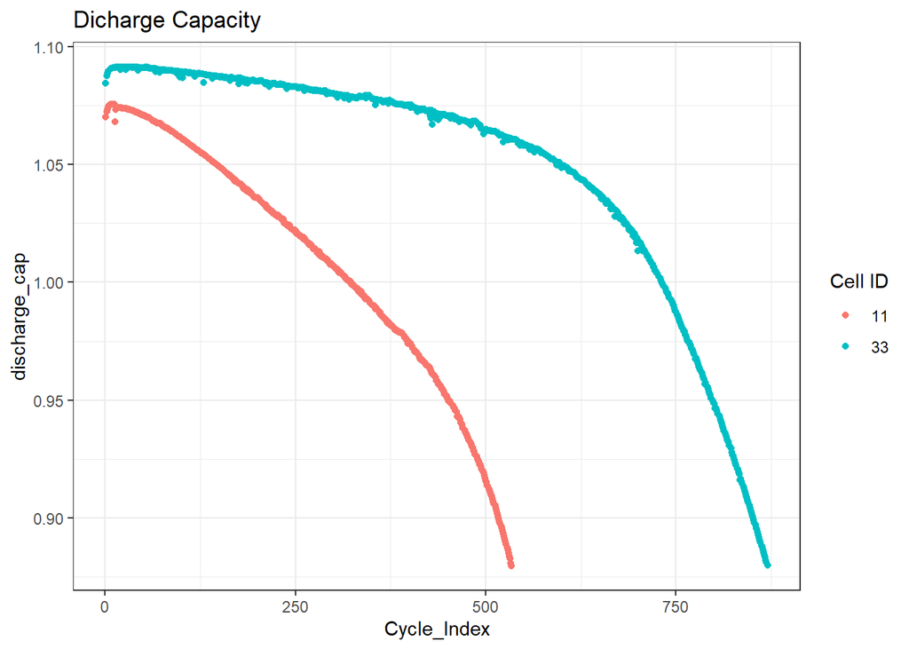

```r
ggplot(cell_summ, aes(x=Cycle_Index, y=discharge_cap, color=as.factor(Cell_id)))+geom_point()+theme_bw()+labs(color="Cell ID", title="Dicharge Capacity")
```

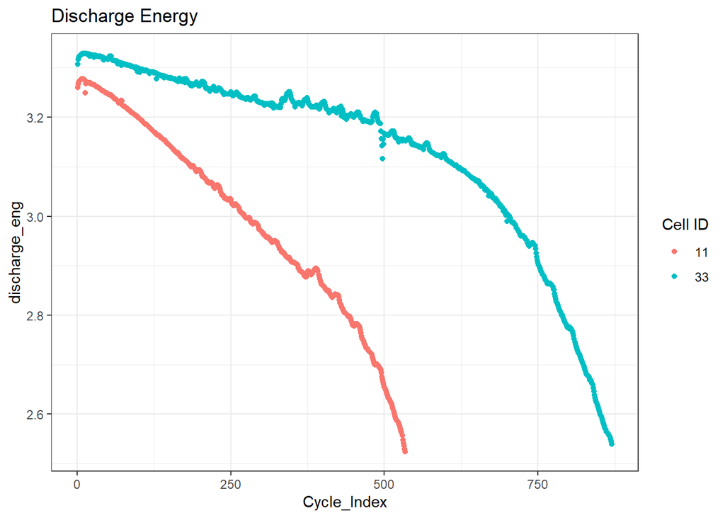

```r
ggplot(cell_summ, aes(x=Cycle_Index, y=discharge_eng, color=as.factor(Cell_id)))+geom_point()+theme_bw()+labs(color="Cell ID", title="Discharge Energy")
```

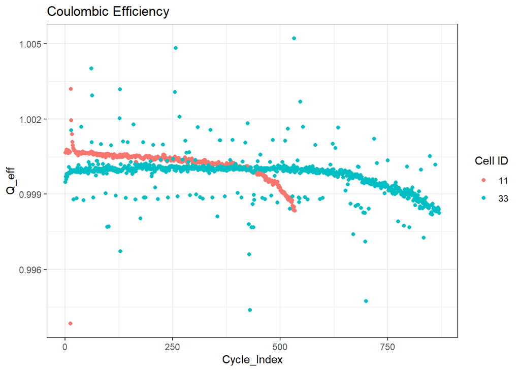

```r
ggplot(cell_summ, aes(x=Cycle_Index, y=Q_eff, color=as.factor(Cell_id)))+geom_point()+theme_bw()+labs(color="Cell ID", title="Coulombic Efficiency")
```

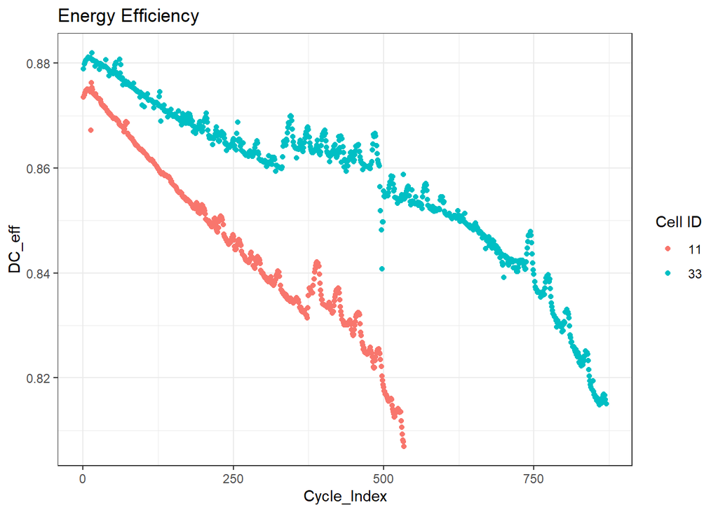

```r
ggplot(cell_summ, aes(x=Cycle_Index, y=DC_eff, color=as.factor(Cell_id)))+geom_point()+theme_bw()+labs(color="Cell ID", title="Energy Efficiency")
```

Since the charging profiles are different for these two cells and the discharge is consistent, we will focus only on the discharge summary statistics.

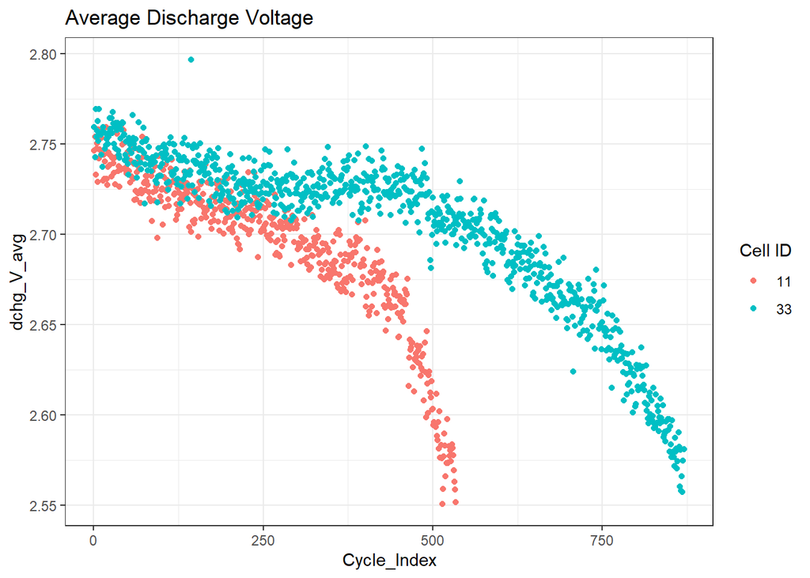

```r
ggplot(cell_summ, aes(x=Cycle_Index, y=dchg_V_avg, color=as.factor(Cell_id)))+geom_point()+labs(color="Cell ID", title="Average Discharge Voltage")+theme_bw()
```

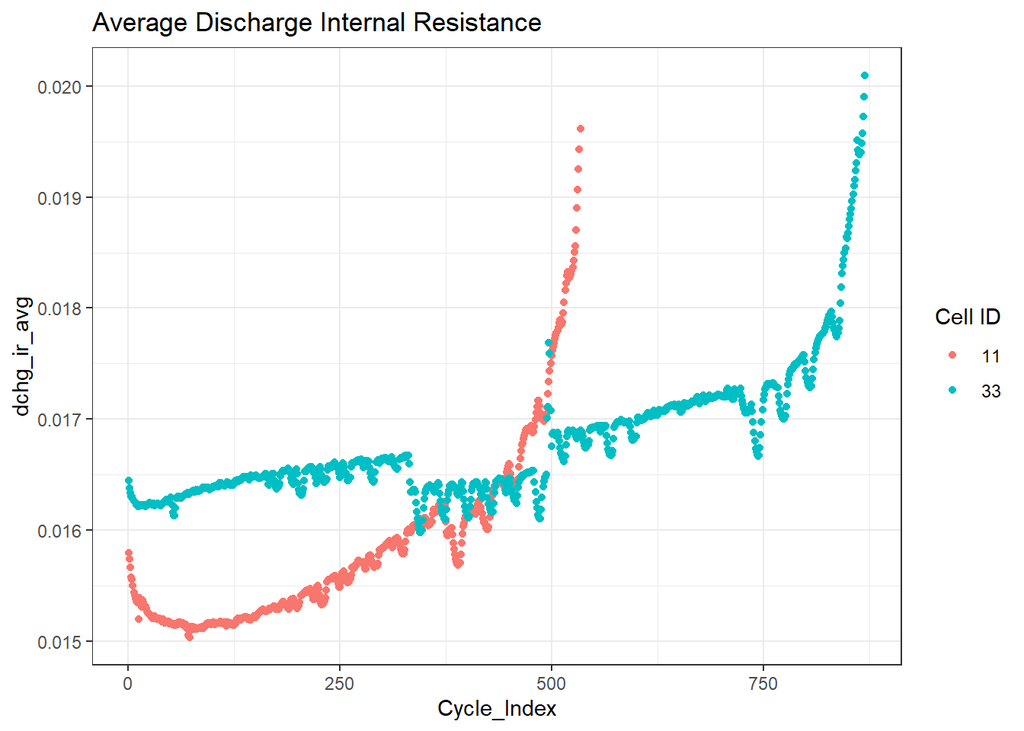

```r
ggplot(cell_summ, aes(x=Cycle_Index, y=dchg_ir_avg, color=as.factor(Cell_id)))+geom_point()+labs(color="Cell ID", title="Average Discharge Internal Resistance")+theme_bw()
```

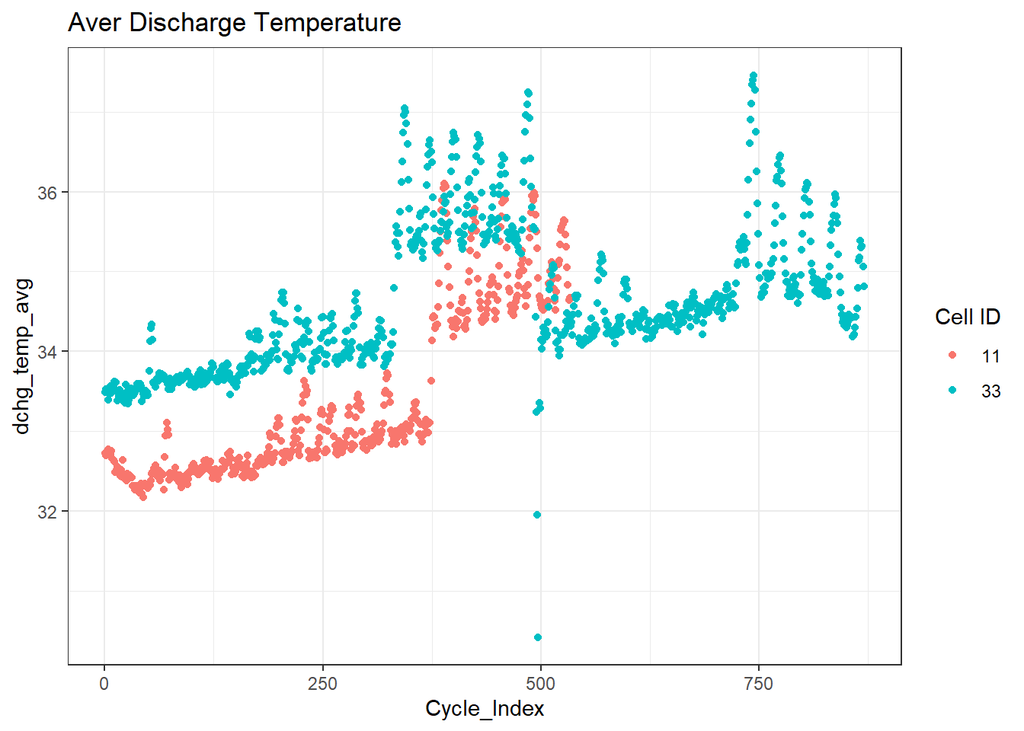

```r
ggplot(cell_summ, aes(x=Cycle_Index, y=dchg_temp_avg, color=as.factor(Cell_id)))+geom_point()+labs(color="Cell ID", title="Aver Discharge Temperature")+theme_bw()
```

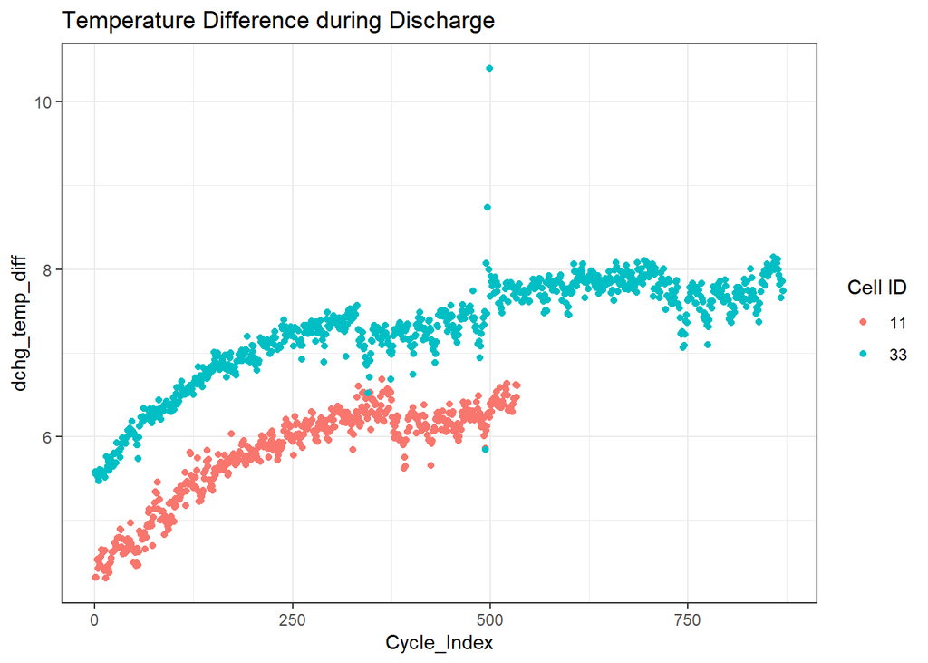

```r
ggplot(cell_summ, aes(x=Cycle_Index, y=dchg_temp_diff, color=as.factor(Cell_id)))+geom_point()+labs(color="Cell ID", title="Temperature Difference during Discharge")+theme_bw()
```

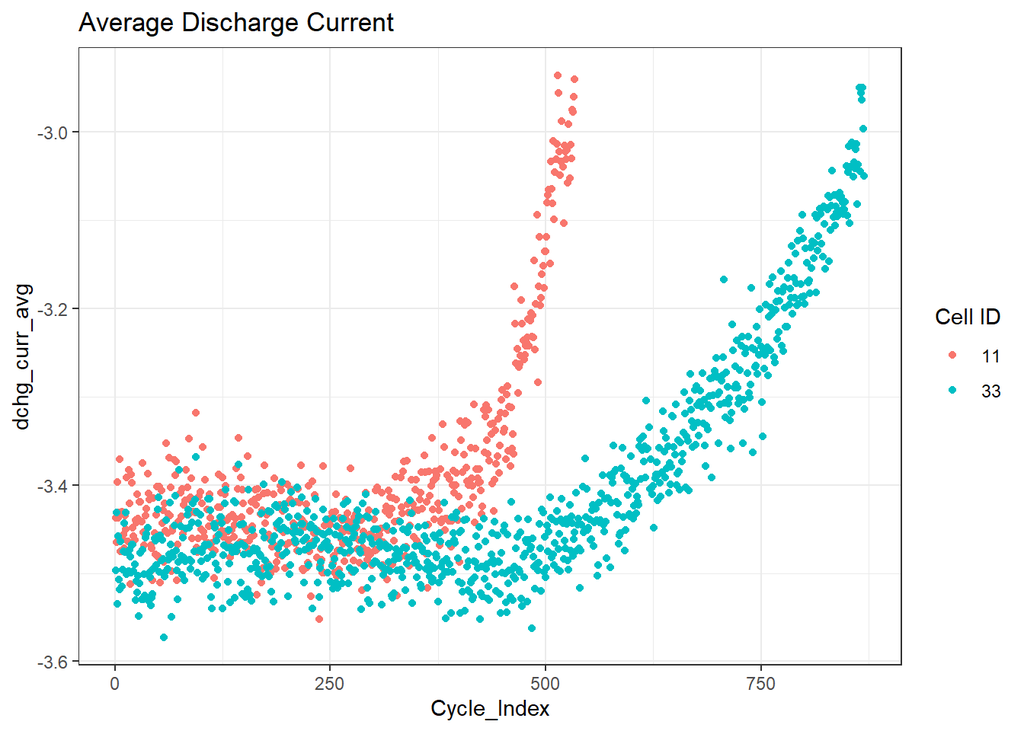

```r
ggplot(cell_summ, aes(x=Cycle_Index, y=dchg_curr_avg, color=as.factor(Cell_id)))+geom_point()+labs(color="Cell ID", title="Average Discharge Current")+theme_bw()
```

One other useful feature that can be used in Battery Analysis to diagnose performance and performance changes is the dQ/dV plot.

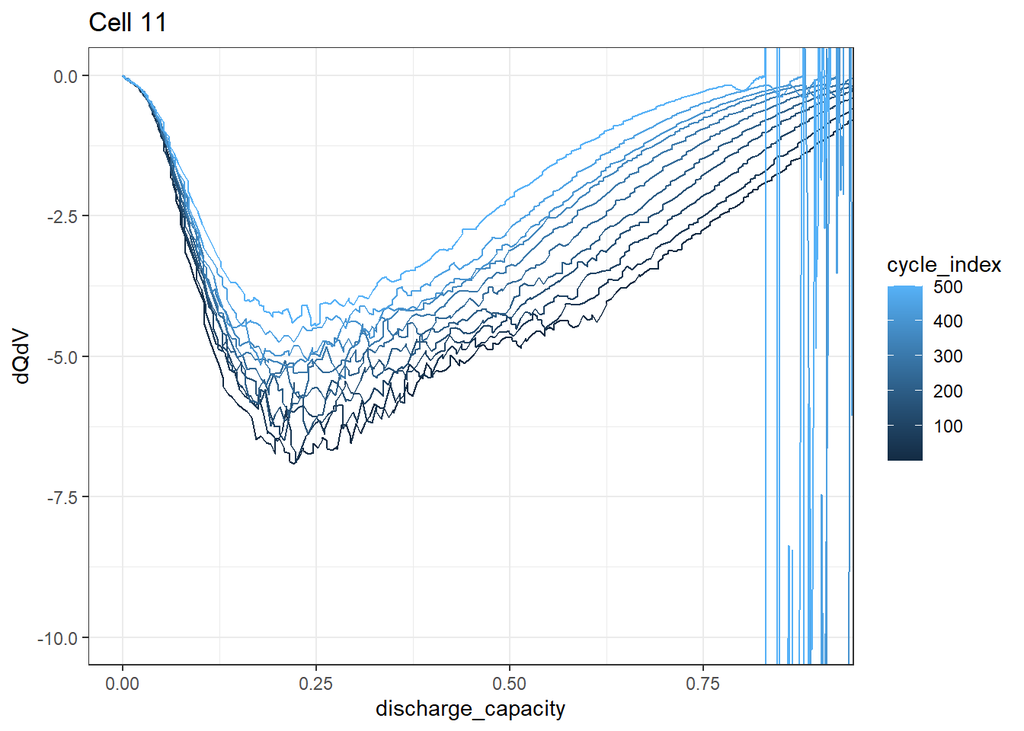

```r
# Simple moving average function
ma <- function(x, n = 5){stats::filter(x, rep(1 / n, n), sides = 2)}

dQdV <- data.frame()
# Only doing 10 cycles, every 50
for(i in 0:10){
  tmp <- cell_1[cell_1$Cycle_Index == (50*i+1) & cell_1$Current < 0,] # Get a single cycle worth of data, discharge only
  b <- diff(tmp$Discharge_Capacity)/diff(tmp$Voltage) # calculate dQ/dV
  b_cln <- zoo::na.approx(b) # Fill in any NaN with interpolation
  b_smth <- ma(b_cln) # Smooth lines

  output_df <- data.frame(cycle_index = (50*i+1), dQdV=c(0,b_smth), discharge_capacity=tmp$Discharge_Capacity)
  dQdV <- rbind(dQdV, output_df)
}

ggplot(dQdV, aes(x=discharge_capacity, y=dQdV, group=cycle_index, color=cycle_index))+geom_line()+coord_cartesian(xlim=c(0, 0.9), ylim=c(-10, 0))+theme_bw()+labs(title="Cell 11")
```

This gave us a pretty good insight into what is happening into the batteries. With only 2 hours to work on the analysis and presentation, we weren’t able to dive into the data as much as needed but here are some next steps:

- Run this same analysis on a large group of cells and then use the features created here to start building models to predict lifetime
- Start to build out feature trends to help predict lifetime
- Baseline features vs the cell starting point to remove variability with initial cell conditions

Below is a function that can run this same analysis given the file path of the cell data

```r
# Function takes in a Path to a data file and returns a list include the original data, summary data, generated plots, and dQdV data.
cell_analysis <- function(path_to_file){

  cell_data <- read.csv(path_to_file)

  # First Cycle
  p1 <- ggplot(cell_data[cell_data$Cycle_Index == 2,], aes(x=Data_Point, y=Voltage))+geom_line()+labs(title="Cycle 2 Cycling")+theme_bw()
  p2 <- ggplot(cell_data[cell_data$Cycle_Index == 2,], aes(x=Data_Point, y=Current))+geom_line()+theme_bw()
  first_cycle_plot <- grid.arrange(p1, p2, nrow=2)+theme_bw()

  # Waterfall Plots
  # Voltage vs Cycle Count
  dchg_voltage <- ggplot(cell_data[cell_data$Cycle_Index %% 50 == 0 & cell_data$Current < 0, ], aes(x=Discharge_Capacity, y=Voltage, group=Cycle_Index, color=Cycle_Index))+geom_line()+theme_bw()+labs(title="Discharging Waterfall")
  chg_voltge <- ggplot(cell_data[cell_data$Cycle_Index %% 50 == 0 & cell_data$Current > 0, ], aes(x=Charge_Capacity, y=Voltage, group=Cycle_Index, color=Cycle_Index))+geom_line()+theme_bw()+labs(title="Charging Waterfall")


    # Internal Resistance vs Cycle Count
  dchg_ir <- ggplot(cell_data[cell_data$Cycle_Index %% 50 == 0 & cell_data$Current < 0, ], aes(x=Discharge_Capacity, y=Internal_Resistance, group=Cycle_Index, color=Cycle_Index))+geom_line()+theme_bw()+labs(title="Discharging IR")
  chg_ir <- ggplot(cell_data[cell_data$Cycle_Index %% 50 == 0 & cell_data$Current > 0, ], aes(x=Charge_Capacity, y=Internal_Resistance, group=Cycle_Index, color=Cycle_Index))+geom_line()+theme_bw()+labs(title="Charging IR")



  # Temp vs Cycle Count
  dchg_temp <- ggplot(cell_data[cell_data$Cycle_Index %% 50 == 0 & cell_data$Current > 0, ], aes(x=Charge_Capacity, y=Temperature, group=Cycle_Index, color=Cycle_Index))+geom_line()+theme_bw()+labs(title="Discharging Temp")
  chg_temp <- ggplot(cell_data[cell_data$Cycle_Index %% 50 == 0 & cell_data$Current < 0, ], aes(x=Discharge_Capacity, y=Temperature, group=Cycle_Index, color=Cycle_Index))+geom_line()+theme_bw()+labs(title="Charging Temp")

  cell_data_summ <- cycle_summary(cell_data)

  # Cycle Summary Plots
  # Discharge Capacity
  dcap <- ggplot(cell_summ, aes(x=Cycle_Index, y=discharge_cap, color=as.factor(Cell_id)))+geom_point()+theme_bw()+labs(color="Cell ID", title="Dicharge Capacity")
  # Discharge Energy
  deng <- ggplot(cell_summ, aes(x=Cycle_Index, y=discharge_eng, color=as.factor(Cell_id)))+geom_point()+theme_bw()+labs(color="Cell ID", title="Discharge Energy")
  #Coulombic Efficiency
  q_eff <- ggplot(cell_summ, aes(x=Cycle_Index, y=Q_eff, color=as.factor(Cell_id)))+geom_point()+theme_bw()+labs(color="Cell ID", title="Coulombic Efficiency")
  # Energy Efficiency
  dc_eff <- ggplot(cell_summ, aes(x=Cycle_Index, y=DC_eff, color=as.factor(Cell_id)))+geom_point()+theme_bw()+labs(color="Cell ID", title="Energy Efficiency")

  # Discharge Cycle Summary Plots
  d_volt <- ggplot(cell_summ, aes(x=Cycle_Index, y=dchg_V_avg, color=as.factor(Cell_id)))+geom_point()+labs(color="Cell ID", title="Average Discharge Voltage")+theme_bw()
  d_ir <= ggplot(cell_summ, aes(x=Cycle_Index, y=dchg_ir_avg, color=as.factor(Cell_id)))+geom_point()+labs(color="Cell ID", title="Average Discharge Internal Resistance")+theme_bw()
  d_temp <- ggplot(cell_summ, aes(x=Cycle_Index, y=dchg_temp_avg, color=as.factor(Cell_id)))+geom_point()+labs(color="Cell ID", title="Aver Discharge Temperature")+theme_bw()
  d_temp_diff <- ggplot(cell_summ, aes(x=Cycle_Index, y=dchg_temp_diff, color=as.factor(Cell_id)))+geom_point()+labs(color="Cell ID", title="Temperature Difference during Discharge")+theme_bw()
  d_curr <- ggplot(cell_summ, aes(x=Cycle_Index, y=dchg_curr_avg, color=as.factor(Cell_id)))+geom_point()+labs(color="Cell ID", title="Average Discharge Current")+theme_bw()

  dQdV <- data.frame()
  # Only doing 10 cycles, every 50
  for(i in 0:10){
    tmp <- cell_1[cell_1$Cycle_Index == (50*i+1) & cell_1$Current < 0,] # Get a single cycle worth of data, discharge only
    b <- diff(tmp$Discharge_Capacity)/diff(tmp$Voltage) # calculate dQ/dV
    b_cln <- zoo::na.approx(b) # Fill in any NaN with interpolation
    b_smth <- ma(b_cln) # Smooth lines

    output_df <- data.frame(cycle_index = (50*i+1), dQdV=c(0,b_smth), discharge_capacity=tmp$Discharge_Capacity)
    dQdV <- rbind(dQdV, output_df)
  }

  dQdV_plt <- ggplot(dQdV, aes(x=discharge_capacity, y=dQdV, group=cycle_index, color=cycle_index))+geom_line()+coord_cartesian(xlim=c(0, 0.9), ylim=c(-10, 0))+theme_bw()+labs(title="Cell 11")

  plot_vec <- c(first_cycle_plot, dchg_voltage, chg_voltge, dchg_ir, chg_ir, dchg_temp, chg_temp, dcap, deng, q_eff, dc_eff, d_volt, d_ir, d_temp, d_temp_diff, d_curr, dQdV_plt)
  return_list <- list("Cell Data" = cell_data, "Cell Summary Data" = cell_data_summ, "Plots" = plot_vec, "dQdV" = dQdV)
  return(return_list)
}
```